# Classifying handwritten digits

Downloading the dataset from Amazon might take a while

```python
# Obtain the MNIST dataset
from keras.datasets import mnist
(X_train, y_train), (X_test, y_test) = mnist.load_data()
```

```python
X_train.shape, y_train.shape
```

```
((60000, 28, 28), (60000,))
```

```python
import numpy as np
np.unique(y_train)
```

```
array([0, 1, 2, 3, 4, 5, 6, 7, 8, 9], dtype=uint8)
```

```python
# Let's see some examples

import matplotlib.pyplot as plt
%matplotlib inline
```

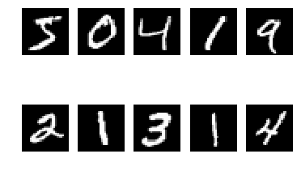

```python
for i in range(10):
    plt.subplot(2, 5, i+1)
    plt.imshow(X_train[i, :, :], cmap='gray')
    plt.axis('off')
```

## Preprocessing

Ideas for preprocessing:

- centering the image,
- scaling so that all digits have the same size,
- representing categorical features: the target abels should be one-hot encoded

```python
# one-hot encoding
# transform the labels from a vector with integers 0-9
# to a matrix with floats 0.0-1.0
from sklearn.preprocessing import OneHotEncoder
enc = OneHotEncoder(sparse=False, dtype=np.float32)
y_train_pre = enc.fit_transform(y_train.reshape(-1,1))
```

```python
y_test_pre = enc.fit_transform(y_test.reshape(-1, 1))
```

Currently, `X_train` and `X_test` are 3-D matrices `<n_samples x 28 x 28>` with integer values between 0 and 255. Preferably, we want a 2-D matrix `<n_samples x n_features>` with floating point numbers, where `n_features` is 784

```python
X_train_pre = X_train.astype(np.float32) / 255.0
X_train_pre = X_train_pre.reshape((X_train.shape[0], -1))
X_test_pre = X_test.astype(np.float32) / 255.0
X_test_pre = X_test_pre.reshape((X_test.shape[0], -1))
```

```python
# set up and train an MLP object in opencv

import cv2
mlp = cv2.ml.ANN_MLP_create()
```

```python
# 1st layer has as many neurons as the input, 784 here
# also last layer must have appropriate size (10)

mlp.setLayerSizes(np.array([784, 512, 512, 10]))
```

```python
# set activation function (sigmoid in this case)
mlp.setActivationFunction(cv2.ml.ANN_MLP_SIGMOID_SYM,\
                          2.5, 1.0)
```

```python
# specify training method (backprop in this case)
# and also, learning rate
mlp.setTrainMethod(cv2.ml.ANN_MLP_BACKPROP)
mlp.setBackpropWeightScale(0.00001)
```

```python
# termination criteria: iterations and/or error
term_mode = (cv2.TERM_CRITERIA_MAX_ITER + \
            cv2.TERM_CRITERIA_EPS)
term_max_iter = 10
term_eps = 0.01
mlp.setTermCriteria((term_mode, term_max_iter, term_eps))
```

**WARNING - WARNING - WARNING**

This might take a while:

> Before you call `mlp.train`, here is a word of caution: this might take several hours to run, depending on your computer setup! For comparison, it took just under an hour on my own laptop. We are now dealing with a real-world dataset of 60,000 samples: if we run 100 training epochs, we have to compute 6 million gradients! So beware.

```python
# get on with the training
mlp.train(X_train_pre, cv2.ml.ROW_SAMPLE, y_train_pre)
#True
```

```
True
```

```python
# accuracy
_, y_hat_train = mlp.predict(X_train_pre)
```

```python
from sklearn.metrics import accuracy_score
accuracy_score(y_hat_train.round(), y_train_pre)
```

```
0.8539166666666667
```

```python
# what really counts is the accuracy score we get on the
# held-out test data
_, y_hat_test = mlp.predict(X_test_pre)
accuracy_score(y_hat_test.round(), y_test_pre)
```

```
0.8488
```

> As you add more neurons to the network, you should see the training score increase--and with it, hopefully, the test score. However, having N neurons in a single layer is not the same as having them spread out over several layers! Can you confirm this observation?

## Referencias

- Beyeler, Michael. 2017. *Machine Learning for Opencv: Intelligent Image Processing with Python*. Vol. 1. Packt Publishing - ebooks Account.